# Part I - Data Exploratory Analysis

*Research project completed by Allysa Grace Fontillas for Udacity's Data Analyst Nanodegree Program | December 02, 2023*

- Introduction
- Data Wrangling
- Univariate Exploration
- Bivariate Exploration
- Multivariate Exploration

## Introduction

In this project, I will explore the Ford GoBike System dataset provided by Udacity. This dataset contains information about rides in Ford's bike-sharing program in the San Francisco Bay Area. This dataset's `bike_share_for_all_trip` column refers to a [discounted GoBike membership](https://mtc.ca.gov/news/ford-gobike-model-equitable-bike-share-access-us-thanks-community-engagement) for eligible riders of low-income.

In the following sections, I will explore this dataset and transform it into a usable form that's suitable for analysis. I will perform univariate, bivariate, and multivariate exploration analyses to gather notable findings and guide my explanatory data analysis. Towards the end of this project, I will divulge my key insights and the significance of each insight in order to emphasize a call to action.

## Data Wrangling

```python
#Imports the libraries I'll be using
import pandas as pd
import numpy as np
import matplotlib.pyplot as plt
import seaborn as sns
```

```python
#Loads in the Dataset
df = pd.read_csv('201902-fordgobike-tripdata.csv')
df.head(3)
```

|  | duration_sec | start_time | end_time | start_station_id | start_station_name | start_station_latitude | start_station_longitude | end_station_id | end_station_name | end_station_latitude | end_station_longitude | bike_id | user_type | member_birth_year | member_gender | bike_share_for_all_trip |
| --- | --- | --- | --- | --- | --- | --- | --- | --- | --- | --- | --- | --- | --- | --- | --- | --- |
| 0 | 52185 | 2019-02-28 17:32:10.1450 | 2019-03-01 08:01:55.9750 | 21.0 | Montgomery St BART Station (Market St at 2nd St) | 37.789625 | -122.400811 | 13.0 | Commercial St at Montgomery St | 37.794231 | -122.402923 | 4902 | Customer | 1984.0 | Male | No |
| 1 | 42521 | 2019-02-28 18:53:21.7890 | 2019-03-01 06:42:03.0560 | 23.0 | The Embarcadero at Steuart St | 37.791464 | -122.391034 | 81.0 | Berry St at 4th St | 37.775880 | -122.393170 | 2535 | Customer | NaN | NaN | No |
| 2 | 61854 | 2019-02-28 12:13:13.2180 | 2019-03-01 05:24:08.1460 | 86.0 | Market St at Dolores St | 37.769305 | -122.426826 | 3.0 | Powell St BART Station (Market St at 4th St) | 37.786375 | -122.404904 | 5905 | Customer | 1972.0 | Male | No |

```python
#Returns the number of rows + columns the dataframe has
df.shape
```

```
(183412, 16)
```

### What is the structure of your dataset?

There are 183,412 entries and 16 columns in this dataframe.

### What is/are the main feature(s) of interest in your dataset?

After carefully looking over the dataframe, I've decided to focus on users' characteristics (user_type, gender, age, bike_share_for_all status) and how ride distribution and duration change with different features (days, stations, user type, gender, age). After I explore the trends and relationships of these variables, I will convey my key insights in my explanatory data analysis.

### What features in the dataset do you think will help support your investigation into your feature(s) of interest?

Overall, features that will support my investigation are user characteristics and ride distribution and duration trends. The questions I want to address in my explanatory data analysis are:

- What trends do we see among the general Ford BikeShare user population?
- What are the top start stations?
- When do top stations thrive?
- How does duration among the top stations look on different days?

```python
df_subset = df[['duration_sec', 'start_time', 'end_time', 'start_station_id', 'start_station_name', 'end_station_id', 'end_station_name', 'user_type', 'member_birth_year', 'member_gender', 'bike_share_for_all_trip']].copy()
df_subset.head(3)
```

|  | duration_sec | start_time | end_time | start_station_id | start_station_name | end_station_id | end_station_name | user_type | member_birth_year | member_gender | bike_share_for_all_trip |
| --- | --- | --- | --- | --- | --- | --- | --- | --- | --- | --- | --- |
| 0 | 52185 | 2019-02-28 17:32:10.1450 | 2019-03-01 08:01:55.9750 | 21.0 | Montgomery St BART Station (Market St at 2nd St) | 13.0 | Commercial St at Montgomery St | Customer | 1984.0 | Male | No |
| 1 | 42521 | 2019-02-28 18:53:21.7890 | 2019-03-01 06:42:03.0560 | 23.0 | The Embarcadero at Steuart St | 81.0 | Berry St at 4th St | Customer | NaN | NaN | No |
| 2 | 61854 | 2019-02-28 12:13:13.2180 | 2019-03-01 05:24:08.1460 | 86.0 | Market St at Dolores St | 3.0 | Powell St BART Station (Market St at 4th St) | Customer | 1972.0 | Male | No |

```python
#Gives a concise summary of the dataframe
df_subset.info()
```

```
<class 'pandas.core.frame.DataFrame'>
RangeIndex: 183412 entries, 0 to 183411
Data columns (total 11 columns):
 #   Column                   Non-Null Count   Dtype
---  ------                   --------------   -----
 0   duration_sec             183412 non-null  int64
 1   start_time               183412 non-null  object
 2   end_time                 183412 non-null  object
 3   start_station_id         183215 non-null  float64
 4   start_station_name       183215 non-null  object
 5   end_station_id           183215 non-null  float64
 6   end_station_name         183215 non-null  object
 7   user_type                183412 non-null  object
 8   member_birth_year        175147 non-null  float64
 9   member_gender            175147 non-null  object
 10  bike_share_for_all_trip  183412 non-null  object
dtypes: float64(3), int64(1), object(7)
memory usage: 15.4+ MB
```

```python
#Gives summary statistics of the dataframe
df_subset.describe()
```

|  | duration_sec | start_station_id | end_station_id | member_birth_year |
| --- | --- | --- | --- | --- |
| count | 183412.000000 | 183215.000000 | 183215.000000 | 175147.000000 |
| mean | 726.078435 | 138.590427 | 136.249123 | 1984.806437 |
| std | 1794.389780 | 111.778864 | 111.515131 | 10.116689 |
| min | 61.000000 | 3.000000 | 3.000000 | 1878.000000 |
| 25% | 325.000000 | 47.000000 | 44.000000 | 1980.000000 |
| 50% | 514.000000 | 104.000000 | 100.000000 | 1987.000000 |
| 75% | 796.000000 | 239.000000 | 235.000000 | 1992.000000 |
| max | 85444.000000 | 398.000000 | 398.000000 | 2001.000000 |

The minimum birth year is 1878. This information suggests that someone was approximately 141 years old when they participated in this bike-share program. Not only is the age of 141 years old an extreme outlier, there is also no record online of anyone living to the age of 123 years old.

```python
df_subset.query('member_birth_year == 1878')
```

|  | duration_sec | start_time | end_time | start_station_id | start_station_name | end_station_id | end_station_name | user_type | member_birth_year | member_gender | bike_share_for_all_trip |
| --- | --- | --- | --- | --- | --- | --- | --- | --- | --- | --- | --- |
| 27370 | 1474 | 2019-02-25 09:28:42.1610 | 2019-02-25 09:53:17.0680 | 15.0 | San Francisco Ferry Building (Harry Bridges Pl... | 386.0 | 24th St at Bartlett St | Customer | 1878.0 | Female | No |

```python
df_subset = df_subset.drop(27370)
#Confirms drop was successful
df_subset.query('member_birth_year == 1878')
```

|  | duration_sec | start_time | end_time | start_station_id | start_station_name | end_station_id | end_station_name | user_type | member_birth_year | member_gender | bike_share_for_all_trip |
| --- | --- | --- | --- | --- | --- | --- | --- | --- | --- | --- | --- |

There is no current [online record](https://en.wikipedia.org/wiki/List_of_the_verified_oldest_people) of anyone who has lived up to 123 years old so I deleted this entry.

```python
df_subset.duplicated().sum()
```

```
0
```

```python
df_subset.isnull().sum()
```

```
duration_sec                  0
start_time                    0
end_time                      0
start_station_id            197
start_station_name          197
end_station_id              197
end_station_name            197
user_type                     0
member_birth_year          8265
member_gender              8265
bike_share_for_all_trip       0
dtype: int64
```

```python
df_subset.nunique()
```

```
duration_sec                 4752
start_time                 183400
end_time                   183396
start_station_id              329
start_station_name            329
end_station_id                329
end_station_name              329
user_type                       2
member_birth_year              74
member_gender                   3
bike_share_for_all_trip         2
dtype: int64
```

```python
#Prints all the values for member_gender`
genderValues = df_subset['member_gender'].unique()
print('Gender values in the dataframe:', genderValues)

#Verifies that all birth years end in '.0' or are NaN values prior to converting the column datatype into an integer
yearValues = df_subset['member_birth_year'].unique()
print('Birth year values in the dataframe:', yearValues)
```

```
Gender values in the dataframe: ['Male' nan 'Other' 'Female']
Birth year values in the dataframe: [1984.   nan 1972. 1989. 1974. 1959. 1983. 1988. 1992. 1996. 1993. 1990.
 1981. 1975. 1978. 1991. 1997. 1986. 2000. 1982. 1995. 1980. 1973. 1985.
 1971. 1979. 1967. 1998. 1994. 1977. 1999. 1987. 1969. 1963. 1976. 1964.
 1965. 1961. 1968. 1966. 1962. 1954. 1958. 1960. 1970. 1956. 1957. 1945.
 1900. 1952. 1948. 1951. 1941. 1950. 1949. 1953. 1955. 1946. 1947. 1931.
 1943. 1942. 1920. 1933. 2001. 1901. 1944. 1928. 1934. 1939. 1930. 1902.
 1910. 1938. 1927.]
```

```python
#Drops rows with missing values (only 4.5% of the dataset)
df_subset = df_subset.dropna()
#Prints number of null values for each series
print(df_subset.isnull().sum())
#Prints remaining number of rows + columns
print(df_subset.shape)
```

```
duration_sec               0
start_time                 0
end_time                   0
start_station_id           0
start_station_name         0
end_station_id             0
end_station_name           0
user_type                  0
member_birth_year          0
member_gender              0
bike_share_for_all_trip    0
dtype: int64
(174951, 11)
```

```python
#Converts the birth year column from float to integers
df_subset['member_birth_year'] = df_subset['member_birth_year'].astype('int')
df_subset['member_birth_year']
```

```
0         1984
2         1972
3         1989
4         1974
5         1959
          ...
183407    1996
183408    1984
183409    1990
183410    1988
183411    1989
Name: member_birth_year, Length: 174951, dtype: int32
```

```python
#Converts start_time and end_time to datetime objects
df_subset['start_time'] = pd.to_datetime(df_subset['start_time'], format='%Y-%m-%d %H:%M:%S.%f', errors='raise')
df_subset['end_time'] = pd.to_datetime(df_subset['end_time'], format='%Y-%m-%d %H:%M:%S.%f', errors='raise')
```

```python
#Gives the min + max of each start_time value and end_time value
print(df_subset['start_time'].min())
print(df_subset['start_time'].max())
print(df_subset['end_time'].min())
print(df_subset['end_time'].max())
```

```
2019-02-01 00:00:20.636000
2019-02-28 23:59:18.548000
2019-02-01 00:04:52.058000
2019-03-01 08:01:55.975000
```

```python
#Renaming some of the columns for consistency and simplicity
df_subset.rename(columns={'start_time':'start_datetime', 'end_time':'end_datetime', 'member_birth_year':'user_birth_year',
                         'member_gender':'user_gender', 'bike_share_for_all_trip':'bike_share_for_all'}, inplace=True)
```

```python
#Since all of the values in start_time and end_time are in the year 2019, this is the year that will be used to calculate approximate user ages in years.
df_subset['user_age'] = 2019 - df_subset['user_birth_year']

#Creates a column for each detail stored in the start_time and end_time columns
df_subset['start_month'] = df_subset['start_datetime'].dt.strftime('%B')
df_subset['start_day'] = df_subset['start_datetime'].dt.strftime('%A')
df_subset['start_hour'] = df_subset['start_datetime'].dt.strftime('%H')

df_subset['end_month'] = df_subset['end_datetime'].dt.strftime('%B')
df_subset['end_day'] = df_subset['end_datetime'].dt.strftime('%A')
df_subset['end_hour'] = df_subset['end_datetime'].dt.strftime('%H')
```

```python
#Changes all station ids from floats -> ints
df_subset['start_station_id'] = df_subset['start_station_id'].astype('int')
df_subset['end_station_id'] = df_subset['end_station_id'].astype('int')
#Changes all hours from objects -> ints
df_subset['start_hour'] = df_subset['start_hour'].astype('int')
df_subset['end_hour'] = df_subset['end_hour'].astype('int')
```

```python
#Creates a new column called "start_time_of_day" that specifies the time of day based on each start_hour
timesOfDay = []
"""
Loop that uses if and elif statements to check the value of `start_hour` and assigns it a value for the new column `start_time_of_day`
depending on the `start_hour` value (Hour that the ride starts at)
11PM-4AM Latenight
5AM-11AM Morning
12PM-5PM Afternoon
6-10PM Night
"""
for time in df_subset['start_hour'].iloc[:]:
    #11PM-4AM latenight
    if time <5 or time >= 23:
        timesOfDay.append("Late Night")
    #5AM-11AM morning
    elif time <12:
        timesOfDay.append("Morning")
    #12PM-5PM afternoon
    elif time < 18:
        timesOfDay.append("Afternoon")
    #6PM-10PM night
    elif time <23:
        timesOfDay.append("Night")
df_subset['start_time_of_day'] = timesOfDay
```

```python
#Rearranges the columns
cleanData = df_subset.iloc[:,[0, 7, 9, 8, 11, 1, 3, 4, 12, 13, 14, 18, 2, 5, 6, 15, 16, 17, 10]]
cleanData.head(1)
```

|  | duration_sec | user_type | user_gender | user_birth_year | user_age | start_datetime | start_station_id | start_station_name | start_month | start_day | start_hour | start_time_of_day | end_datetime | end_station_id | end_station_name | end_month | end_day | end_hour | bike_share_for_all |
| --- | --- | --- | --- | --- | --- | --- | --- | --- | --- | --- | --- | --- | --- | --- | --- | --- | --- | --- | --- |
| 0 | 52185 | Customer | Male | 1984 | 35 | 2019-02-28 17:32:10.145 | 21 | Montgomery St BART Station (Market St at 2nd St) | February | Thursday | 17 | Afternoon | 2019-03-01 08:01:55.975 | 13 | Commercial St at Montgomery St | March | Friday | 8 | No |

```python
#Arranges start_time_of_day into an ordered categorical type
dayTimes = ['Morning', 'Afternoon', 'Night', 'Late Night']
dtOrdered= pd.CategoricalDtype(ordered=True, categories=dayTimes)
cleanData['start_time_of_day'] = cleanData['start_time_of_day'].astype(dtOrdered);
```

```python
cleanData.describe()
```

|  | duration_sec | user_birth_year | user_age | start_datetime | start_station_id | start_hour | end_datetime | end_station_id | end_hour |
| --- | --- | --- | --- | --- | --- | --- | --- | --- | --- |
| count | 174951.000000 | 174951.000000 | 174951.000000 | 174951 | 174951.000000 | 174951.000000 | 174951 | 174951.000000 | 174951.000000 |
| mean | 703.998342 | 1984.803745 | 34.196255 | 2019-02-15 21:27:00.590339328 | 139.002835 | 13.456191 | 2019-02-15 21:38:45.087658752 | 136.603060 | 13.609559 |
| min | 61.000000 | 1900.000000 | 18.000000 | 2019-02-01 00:00:20.636000 | 3.000000 | 0.000000 | 2019-02-01 00:04:52.058000 | 3.000000 | 0.000000 |
| 25% | 323.000000 | 1980.000000 | 27.000000 | 2019-02-08 08:32:16.261500160 | 47.000000 | 9.000000 | 2019-02-08 08:42:32.211000064 | 44.000000 | 9.000000 |
| 50% | 510.000000 | 1987.000000 | 32.000000 | 2019-02-15 22:19:52.992999936 | 104.000000 | 14.000000 | 2019-02-15 22:33:37.921999872 | 101.000000 | 14.000000 |
| 75% | 789.000000 | 1992.000000 | 39.000000 | 2019-02-22 11:21:55.024999936 | 239.000000 | 17.000000 | 2019-02-22 11:36:51.507000064 | 238.000000 | 18.000000 |
| max | 84548.000000 | 2001.000000 | 119.000000 | 2019-02-28 23:59:18.548000 | 398.000000 | 23.000000 | 2019-03-01 08:01:55.975000 | 398.000000 | 23.000000 |
| std | 1642.208567 | 10.115538 | 10.115538 | NaN | 111.648744 | 4.734284 | NaN | 111.334357 | 4.748030 |

```python
cleanData.query('user_age >= 100').value_counts().sum()
```

```
71
```

I noticed that there are a number of elderly users, some being 100 years old or older. Generally, I would think these outliers stemmed from data entry errors. I cannot validate whether this information is accurate. To avoid assuming peoples' lifestyle activities and capabilities, I decided to keep this data in my analysis.

```python
#Saves the clean file to a CSV
cleanData.to_csv('clean201902_fordgobike.csv', encoding='utf-8', index=False)
```

### Univariate Exploration

#### Exploring User Characteristics

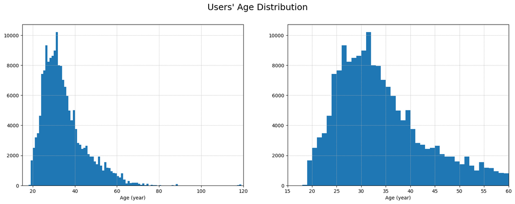

```python
#Setting up the figure for 2 plots side by side
plt.figure(figsize=[18,6])

#Histogram (on the left axis)
plt.subplot(1, 2, 1)
bins= np.arange(0, cleanData['user_age'].max()+1, 1)
plt.hist(data=cleanData, x='user_age', bins=bins);
plt.xlim(15,120);
plt.grid(True, linewidth='.5', linestyle='--')
plt.xlabel('Age (year)');

#Close up (on the right axis)
plt.subplot(1, 2, 2)
plt.hist(data=cleanData, x='user_age', bins=bins);
plt.xlim(15,60);
plt.grid(True, linewidth='.5', linestyle='--')
plt.xlabel('Age (year)');
plt.suptitle("Users' Age Distribution", fontsize=18);
```

The data presents a bimodal structure forming with a rightward skew. There is a peak at around 26 years old and a second peak at around 31 years old. The minimum age is 18 and the maximum age is 119.

From the graph, we can see that most users in Ford's GoBike system are around 23-40 years old.

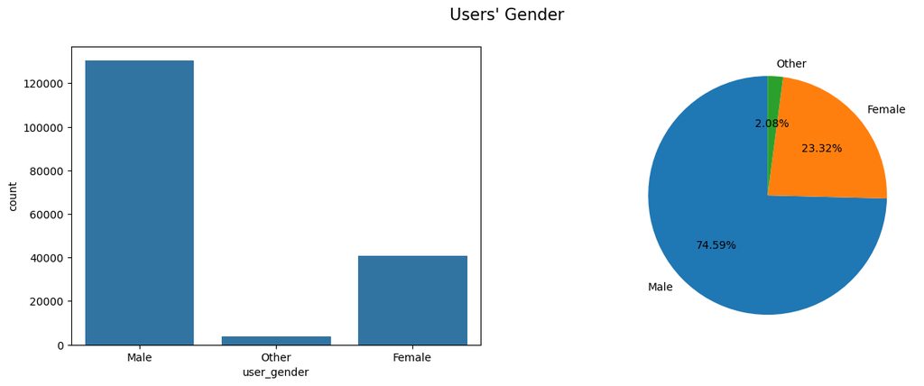

```python
#Setting up the figure for 2 plots side by side
plt.figure(figsize=[15,5])

#Count plot (on the left)
plt.subplot(1, 2, 1)
sns.countplot(data=cleanData, x='user_gender',);

#Pie chart (on the right)
plt.subplot(1, 2, 2)
gendersProp = cleanData['user_gender'].value_counts(normalize=True)
groups = 'Male', 'Female', 'Other'
#Creates my pie chart with the values above and sets it up to displays the values as percentages rounded to the nearest hundredth
plt.pie(gendersProp, labels=groups, autopct='%1.2f%%', startangle=90)
plt.suptitle("Users' Gender", fontsize=15);
plt.show()
```

Approximately 74.60% of the rides in the dataset consist of male users, whereas only 23.32% of rides consist of female users. Less than 2.1% of users identified as "other".

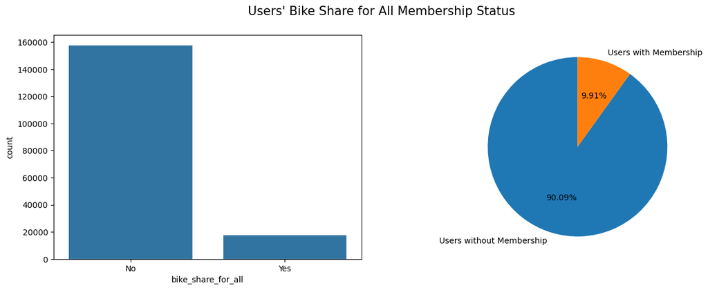

```python
#Setting up the figure for 2 plots side by side
plt.figure(figsize=[15,5])

#Count plot (on the left)
plt.subplot(1, 2, 1)
sns.countplot(data=cleanData, x='bike_share_for_all',);

#Pie chart (on the right)
plt.subplot(1, 2, 2)
bikeProgram = cleanData['bike_share_for_all'].value_counts(normalize=True)
groups = 'Users without Membership', 'Users with Membership'
#Creates my pie chart with the values above and sets it up to displays the values as percentages rounded to the nearest hundredth
plt.pie(bikeProgram, labels=groups, autopct='%1.2f%%', startangle=90)
plt.suptitle("Users' Bike Share for All Membership Status", fontsize=15);
plt.show()
```

*Bike Share for All* is a discounted Ford GoBike membership that is offered to eligible low-income users. 90.09% of rides were from users not enrolled in Ford's GoBike membership and 9.91% are enrolled in Ford's GoBike membership. Overall, only about 10% of all Ford GoBike rides in this dataset are from users who have a *Bike Share for All* membership.

#### Ride Duration Distribution

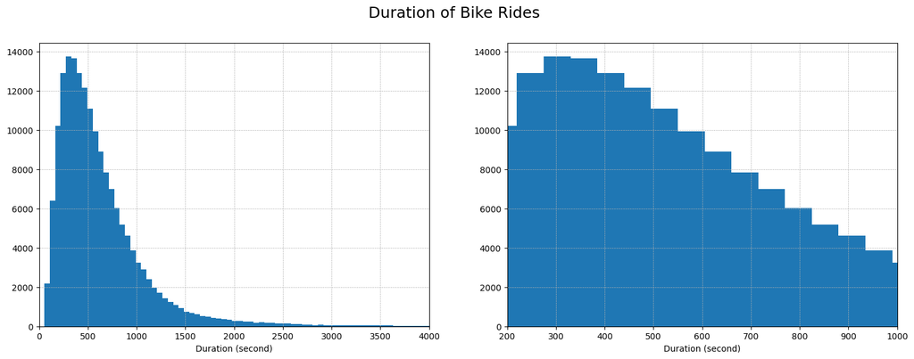

```python
#Setting up the figure for 2 plots side by side
plt.figure(figsize=[18,6])

#Main histogram (on the left axis)
plt.subplot(1, 2, 1)
bins= np.arange(0, cleanData['duration_sec'].max()+55, 55)
plt.hist(data=cleanData, x='duration_sec', bins=bins);
plt.xlim(0,4000);
plt.grid(True, linewidth='.5', linestyle='--')
plt.xlabel('Duration (second)');

##Close up view of the graph to the right of the peak (on the right axis)
plt.subplot(1, 2, 2)
plt.hist(data=cleanData, x='duration_sec', bins=bins)
plt.xlim(200,1000);
plt.grid(True, linewidth='.5', linestyle='--')
plt.xlabel('Duration (second)');
plt.suptitle('Duration of Bike Rides', fontsize=18);
```

This graph presents a unimodal histogram with a right-skewed distribution. The `duration_sec` variable hits a peak in the 200-500 range. Most trips appear to be less than 800 seconds, with trips that are 1000 seconds or more being significantly less popular than those under 800 seconds. I presumed that most people would use a BikeShare service to transport themselves from point A to point B regularly, so a high amount of shorter trips makes sense.

#### Ride Distribution by Top Stations

```python
print('Number of Different Start Stations:', cleanData.start_station_name.nunique())
print('Number of Different End Stations:', cleanData.end_station_name.nunique())
```

```
Number of Different Start Stations: 329
Number of Different End Stations: 329
```

```python
#Outputs the top 7 start stations
cleanData.start_station_name.value_counts().head(7)
```

```
start_station_name
Market St at 10th St                                         3649
San Francisco Caltrain Station 2  (Townsend St at 4th St)    3408
Berry St at 4th St                                           2952
Montgomery St BART Station (Market St at 2nd St)             2711
Powell St BART Station (Market St at 4th St)                 2620
San Francisco Caltrain (Townsend St at 4th St)               2577
San Francisco Ferry Building (Harry Bridges Plaza)           2540
Name: count, dtype: int64
```

```python
#Outputs the top 7 end stations
cleanData.end_station_name.value_counts().head(7)
```

```
end_station_name
San Francisco Caltrain Station 2  (Townsend St at 4th St)    4624
Market St at 10th St                                         3709
Montgomery St BART Station (Market St at 2nd St)             3461
San Francisco Ferry Building (Harry Bridges Plaza)           3151
San Francisco Caltrain (Townsend St at 4th St)               2870
Powell St BART Station (Market St at 4th St)                 2854
Berry St at 4th St                                           2782
Name: count, dtype: int64
```

```python
#The top 7 start stations are also in the top 7 end stations, so I will create subsets of the cleanData dataframe with these stations
stations = ['Market St at 10th St', 'San Francisco Caltrain Station 2  (Townsend St at 4th St)', 'Berry St at 4th St',
            'Montgomery St BART Station (Market St at 2nd St)', 'Powell St BART Station (Market St at 4th St)', 'San Francisco Caltrain (Townsend St at 4th St)',
            'San Francisco Ferry Building (Harry Bridges Plaza)']

startStations = cleanData.loc[cleanData['start_station_name'].isin(stations)]
endStations = cleanData.loc[cleanData['end_station_name'].isin(stations)]
```

```python
#Saves the clean startStations subset to a CSV file for later use
startStations.to_csv('clean_stationsfordgobike.csv', encoding='utf-8', index=False)
```

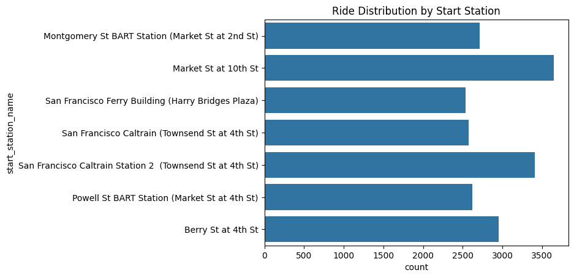

```python
#Horiziontal Bar Chart for top start stations to ensure the long station names are legible
sns.countplot(data=startStations, y='start_station_name');
plt.title("Ride Distribution by Start Station", fontsize=12);
```

The graph above consists of the top 7 `start_station_name`s with the most rides. Market St at 10th St has the highest amount of rides among the top start stations. San Francisco Ferry Building has the lowest amount of rides among the top start stations. Market St at 10 St and San Francisco Caltrain station each have over 400 more rides than the other top stations.

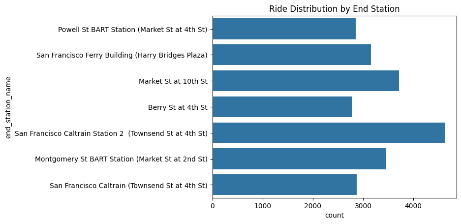

```python
#Horiziontal Bar Chart for top end stations
sns.countplot(data=endStations, y='end_station_name');
plt.title("Ride Distribution by End Station", fontsize=12);
```

The graph above consists of the top 7 `end_station_name`s with the most rides. San Francisco Caltrain Station 2 appears to be a popular end destination for many riders. This station has the most rides out of the top end stations. Berry St at 4th St has the lowest amount of rides among the top end stations.

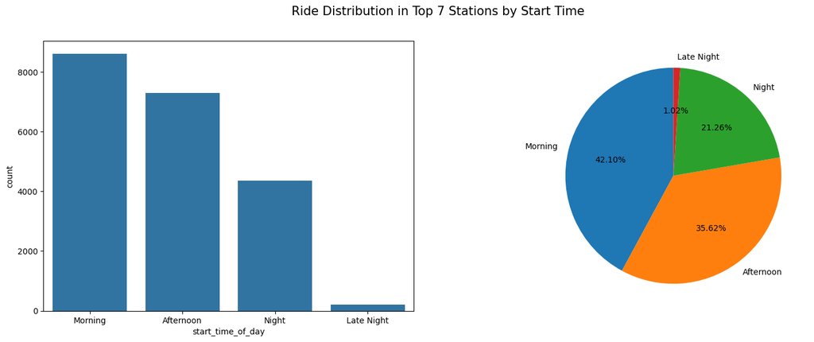

```python
#Arranges start_time_of_day into an ordered categorical type
dayTimes = ['Morning', 'Afternoon', 'Night', 'Late Night']
dtOrdered= pd.CategoricalDtype(ordered=True, categories=dayTimes)

#The warning for the line below does not appear to be correct. Even when I change it to the suggested syntax, a warning occurs.
#And when I change it to "startStations.loc['start_time_of_day'].astype(daysOrdered)" it will work initially,
#but it does not work when I restart the kernel and run all cells
startStations['start_time_of_day'] = startStations['start_time_of_day'].astype(dtOrdered);

#Setting up the figure for 2 plots side by side
plt.figure(figsize=[18,6])
#Countplot (on the left axis)
plt.subplot(1, 2, 1)
sns.countplot(data=startStations, x='start_time_of_day');

timePeriods = startStations['start_time_of_day'].value_counts(normalize=True)
#Creates my pie chart with the values above and sets it up to displays the values as percentages rounded to the nearest hundredth
plt.subplot(1, 2, 2)
dayTimes = ['Morning', 'Afternoon', 'Night', 'Late Night']
plt.pie(timePeriods, labels=dayTimes, autopct='%1.2f%%', startangle=90)
plt.suptitle("Ride Distribution in Top 7 Stations by Start Time", fontsize=15);
plt.show()
```

The graphs above display how many rides occured at a specific time of day for the top 7 `start_station_name`s.

Most bike rides that begin at one of the top 7 stations occur in the morning (*5AM-11AM*) and the least bike rides occur late at night (*11PM-4AM*). The majority of bike rides at these stations occur in the morning or the afternoon (77.72%). This result is unsurprising. I expected most BikeShare users to use the bikes go to work, school, or events during the day.

### Bivariate Exploration

#### Relationship Between Duration and Age

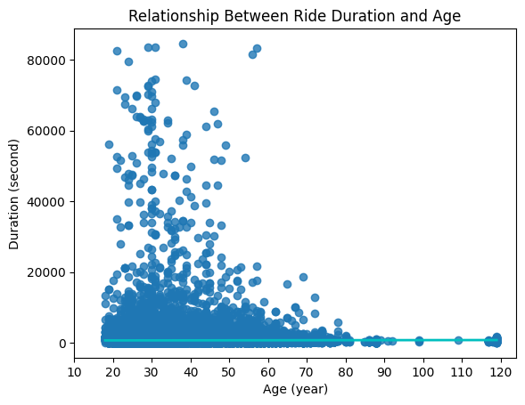

```python
#Plots the scatterplot
sns.regplot(data=cleanData, x='user_age', y='duration_sec', line_kws={'color':'c','lw':2});
plt.xlabel('Age (year)');
plt.ylabel('Duration (second)');
plt.title("Relationship Between Ride Duration and Age", fontsize=12);
yticks = [10,20,30,40,50,60,70,80,90,100,110,120];
plt.xticks(yticks);
```

Most of the rides with higher duration are seen around among users who are in the 20-50 age range.

Since most of the rides are from users who are around 23-40 years old (as seen in the previous graph), I anticipated that this group would have a higher ride duration on average. There are disproportionately less users from the older population. There is no correlation between age and ride duration, evident by the straight regression line.

#### Ride Duration by User Type

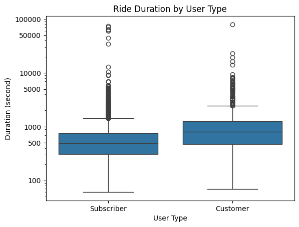

```python
#Creates a sample
np.random.seed(10)
sample = np.random.choice(cleanData.shape[0], 10000, replace=False)
df_sample = cleanData.iloc[sample]
#Plots boxplot
ax= sns.boxplot(data=df_sample, y='duration_sec', x='user_type')
ax.set_yscale('log')

numyticks = [100, 500, 1000, 5000, 10000, 50000, 100000]
label = [f'{n}' for n in numyticks]
plt.yticks(numyticks, label)

plt.title("Ride Duration by User Type", fontsize=12);
plt.ylabel('Duration (second)');
plt.xlabel('User Type');
```

Users who are casual customers tend to have longer ride durations than users with a Ford BikeShare subscription. There are many outliers that are higher than the values in the upper quartile range and maximum of each `user_type`.

I created this plot with a random sample to reduce clutter and increase visual clarity. I also conducted a log transformation on this graph to reduce skewness.

#### Ride Distribution by User Type

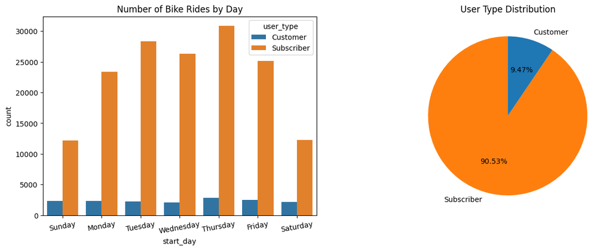

```python
#Setting up the figure for 2 plots side by side
plt.figure(figsize=[15,5])
#Converts the end_days column into an ordered categorical data type
days=['Sunday', 'Monday', 'Tuesday', 'Wednesday', 'Thursday', 'Friday', 'Saturday']
daysOrdered = pd.CategoricalDtype(ordered=True, categories=days)
cleanData['start_day'] = cleanData['start_day'].astype(daysOrdered);

#Plots a clustered bar chart
plt.subplot(1, 2, 1)
colors = ['tab:blue','tab:orange']
sns.countplot(data=cleanData, x='start_day', hue='user_type', palette=colors);
plt.xticks(rotation=10);
plt.title('Number of Bike Rides by Day', fontsize=12);

#Pie chart (on the right)
plt.subplot(1, 2, 2)
memberProp = cleanData['user_type'].value_counts(normalize=True)
groups = 'Subscriber', 'Customer'
colors = ['tab:orange', 'tab:blue']
#Creates my pie chart with the values above and sets it up to displays the values as percentages rounded to the nearest hundredth
plt.pie(memberProp, labels=groups, autopct='%1.2f%%', startangle=90, colors=colors);
plt.title("User Type Distribution", fontsize=12);
```

Thursday had the highest amount of rides. Most rides occured during the weekday, Monday through Friday. The weekend had the least amount of rides.

The majority of rides were carried out by subscribers, which makes sense considering 90.53% of users in the dataset are subscribers.

### Multivariate Exploration

#### Top Stations' Duration and their Duration by Day

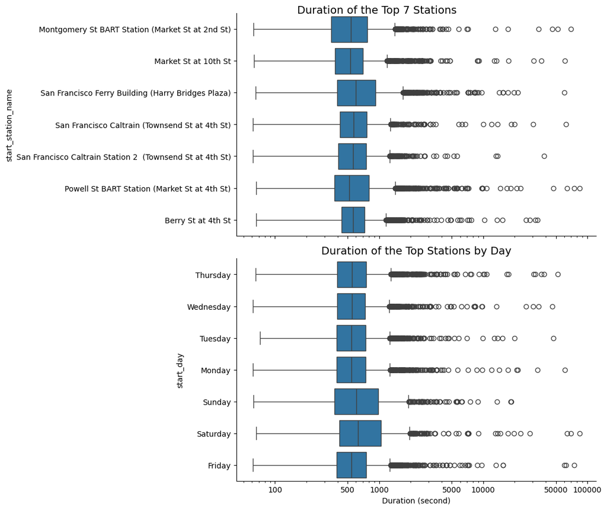

```python
#Plots a plot matrix with Seaborn's PairGrid function
g = sns.PairGrid(data=startStations, x_vars=['duration_sec'], y_vars=['start_station_name', 'start_day'])
g.fig.set_size_inches(10,10)
g.map(sns.boxplot)

cols = ['start_station_name', 'start_day', 'duration_sec']
for ax in g.axes.flat:
    if ax.get_xlabel() in cols:
        ax.set(xscale='log')

#Converts the important days from startStations into an ordered categorical data type
days=['Sunday', 'Monday', 'Tuesday', 'Wednesday', 'Thursday', 'Friday', 'Saturday']
daysOrdered = pd.CategoricalDtype(ordered=True, categories=days)

#The warning for the line below does not appear to be correct. Even when I change it to the suggested syntax, a warning occurs.
#And when I change it to "startStations.loc['start_day'].astype(daysOrdered)" it will work initially,
#but it does not work when I restart the kernel and run all cells
startStations['start_day'] = startStations['start_day'].astype(daysOrdered)

numxticks = [100, 500, 1000, 5000, 10000, 50000, 100000]
label = [f'{n}' for n in numxticks]
plt.xticks(numxticks, label);

plt.xlabel('Duration (second)');
plt.suptitle('Duration of the Top 7 Stations', fontsize=14);
plt.title('Duration of the Top Stations by Day', fontsize=14);
```

I performed a log transformation on this graph for visual acuity.

Recall that the `start_station_names` in the startStations dataframe only consist of the top 7 most popular stations. Notice that most of the top 7 starting stations offer transit services such as ferry or train.

Saturday had the highest duration on average and Sunday had the second highest. In general, the weekend had higher durations than the weekdays. Let's take a look at these variables on a faceted histogram.

#### Ride Distribution By Start Day and Duration of the Top 7 Start Stations

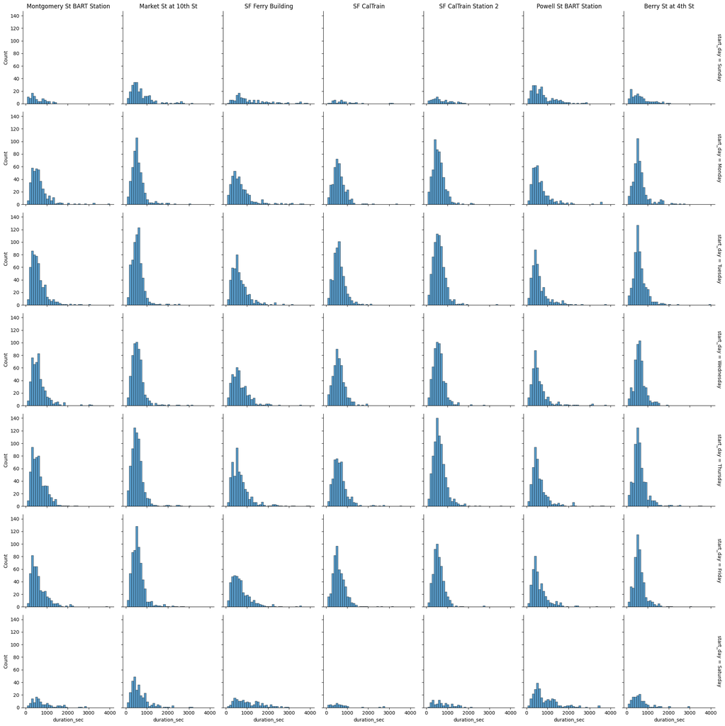

```python
#Same variables as above but in a faceted histogram
g = sns.FacetGrid(startStations, col='start_station_name', row='start_day', margin_titles=True)
g.map_dataframe(sns.histplot, x='duration_sec', binwidth=100, binrange=(60, 4000));

#Sets up custom margin_titles
for ax, title in zip(g.axes.flat, ['Montgomery St BART Station', 'Market St at 10th St', 'SF Ferry Building', 'SF CalTrain', 'SF CalTrain Station 2',
                                  'Powell St BART Station', 'Berry St at 4th St']):
    ax.set_title(title)
```

The graph presents ride duration distribution for each of the top 7 start stations. It is organized by day of the week; each row is for a particular day.

- Market St at 10th St is the most popular station during the weekdays. San Francisco Caltrain Station 2 and Berry St at 4th St are also quite popular during the weekdays.
- Market St is the most popular station on the weekend and Powell St BART Station is the 2nd most popular station on the weekend.
- San Francisco CalTrain has the lowest amount of rides *and* shortest ride durations on the weekend.
- Overall, longer ride durations appear to stem from the San Francisco Ferry Building station.

#### Duration Distribution by Day and Gender

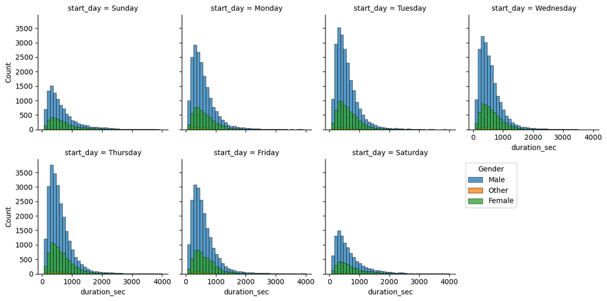

```python
#Facet histogram on duration count by day and gender
g = sns.FacetGrid(cleanData, col='start_day', hue='user_gender', col_wrap=4, margin_titles=True)
g.map_dataframe(sns.histplot, x='duration_sec', binwidth=100, binrange=(60, 4000));
plt.legend(title='Gender', bbox_to_anchor=(1.5,1));
```

All visualizations are unimodal with a rightward skew. Thursday saw the highest amount of rides from males and females. The weekend had the lowest amount of rides from all genders. As expected, there are a higher amount of rides with a shorter duration than those with a longer duration.

A previous boxplot showed that the weekend has a higher ride duration on average. However, this isn't particularly evident in this histogram. I suspect that it is because there are less rides on the weekend. A lower amount of rides may have skewed the duration average to appear higher than other days with a higher amount of rides.

## Summary

I found many interesting features in the dataset. I was surprised that almost 75% of users in the dataset are males. Prior to conducting my analysis, I the ride distribution between genders would be more equal and not so disproportionate. I was unsurprised to see that most users were around 23-40 years old considering young people tend to do more physical activities. San Francisco is known for its hills so I speculate that biking in this area can be quite the workout.

It seems that most users use the bikes to go from point A to point B. My analysis revealed that most trips are less than 800 seconds (13.33 minutes). This is understandable. I suspect that a lot of users utilize this bikeshare service to travel to and from work or school. I noticed that the stations that fared the most rides are areas that are popular for transportation or for tourists. My analysis also revealed that bike rides at top stations are more popular in the morning and in the afternoon.

### References

- [Stack Overflow](https://stackoverflow.com/questions/74848562/how-to-change-to-datetime-format-date-with-dashes) To get an idea of how to convert a series to datetime object with spaces + dashes
- [StackOverflow](https://stackoverflow.com/questions/33446029/how-to-change-a-figures-size-in-python-seaborn-package) Taught me how to change figsize for Seaborn's Pairgrids
- [StackOverflow](https://stackoverflow.com/questions/71842013/seaborn-pairplot-with-log-scale-only-for-specific-columns) Taught me how to set log scale for Pairgrids
- [StackOverflow](https://stackoverflow.com/questions/31632372/customizing-annotation-with-seaborns-facetgrid) Guided me on how to customize margin titles for a FacetGrid
- [Metropolitan Transportation Commission](https://mtc.ca.gov/news/ford-gobike-model-equitable-bike-share-access-us-thanks-community-engagement) Explained what "Bike Share for All" is
- [Strftime](https://strftime.org/) Used for formatting datetime object conversion
- [Enterprise DNA Blog](https://blog.enterprisedna.co/python-datetime/#:~:text=datetime%20also%20allows%20you%20to,datetime%20object%20as%20a%20string.&text=This%20code%20will%20print%20the,month%20name%20in%20the%20output.) Explained how to use the .strftime() method